# 2YP FOX

### METHODS

#### 1. Participants

317 (69% female) English speakers aged 17 to 33 were recruited from the experimental-subject pool at a large public university in the United States (M(age) = 20.5, SD(age) = 2.19). Participants completed three activities: two graph reading tasks followed by a drawing task. In some cases (order = linear-first), participants (n = 155) completed the first graph reading task with a linear model graph, followed by the task with the triangular graph. To control for any effects of graph order on performance, an additional (n= 162) subjects completed the activities with the graphs in reverse order. Each participant was randomly assigned to one of five conditions which determined what additional information (scaffold) they received while solving the first five problems on each graph reading task: no-scaffold (control), ‘what’ text, ‘how’-text, static-image, interactive-image. The runtime of the entire study ranged from 22 to 66 minutes (M = 40, SD = 8.56).

In addition, we ran 6 expert participants through two conditions, composed of research assistants with more than 20 hours of experience analyzing data with the triangular model graph.

#### 2. Results: Response Latency

##### Explore the data

```
       Linear      Triangular
```

CONDITION mean sd mean sd  
0 8.6 2.1 11.2 3.6 1 9.8 3.0 11.6 3.6 2 9.1 2.3 10.9 3.0 3 9.1 2.6 10.8 3.4 4 9.4 2.6 9.9 2.6 All 9.2 2.5 10.8 3.3

```
 Linear      Triangular
 mean   sd   mean       sd
```

All 10.7 2.6 9.5 2.3

##### Construct a mixed effects ANOVA

1. Explore descriptives for each factor
2. Construct contrasts
3. compute the ANOVA model

```
Converting "subject" to factor for ANOVA.Data is unbalanced (unequal N per group). Make sure you specified a well-considered value for the type argument to ezANOVA().
```

|  | Effect | DFn | DFd | F | p | p<.05 | ges |
| --- | --- | --- | --- | --- | --- | --- | --- |
| 2 | condition | 4 | 297 | 1.15303780 | 3.317695e-01 |  | 1.166433e-02 |
| 3 | order | 1 | 297 | 0.03373861 | 8.543893e-01 |  | 8.632596e-05 |
| 4 | lm_scenarios | 1 | 297 | 2.62101269 | 1.065185e-01 |  | 6.662201e-03 |
| 9 | variable | 1 | 297 | 110.67488966 | 3.290208e-22 | * | 8.209539e-02 |
| 5 | condition:order | 4 | 297 | 0.71522404 | 5.820739e-01 |  | 7.267516e-03 |
| 6 | condition:lm_scenarios | 4 | 297 | 1.69618986 | 1.508091e-01 |  | 1.706518e-02 |
| 7 | order:lm_scenarios | 1 | 297 | 1.46220706 | 2.275410e-01 |  | 3.727680e-03 |
| 10 | condition:variable | 4 | 297 | 3.48175747 | 8.478153e-03 | * | 1.112936e-02 |
| 11 | order:variable | 1 | 297 | 44.19984573 | 1.419857e-10 | * | 3.448666e-02 |
| 12 | lm_scenarios:variable | 1 | 297 | 8.28299619 | 4.292159e-03 | * | 6.649091e-03 |

[output cut: 5 more lines]

```
NA
```

4. Interpret significant effects  
   `Main Effect: Graph Type`

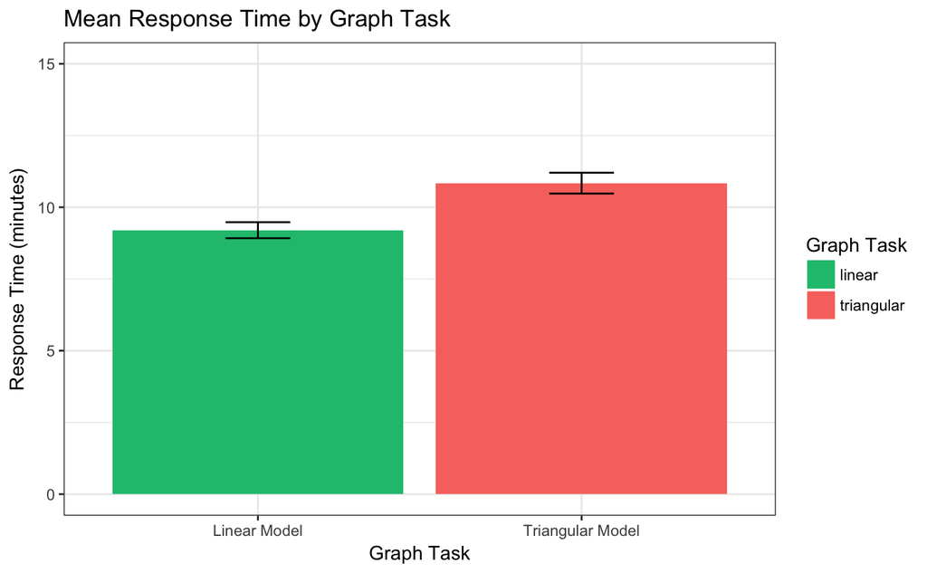

`IXN Graph Type & Scaffold` There was a significant interaction between graph-type and the scaffold condition,

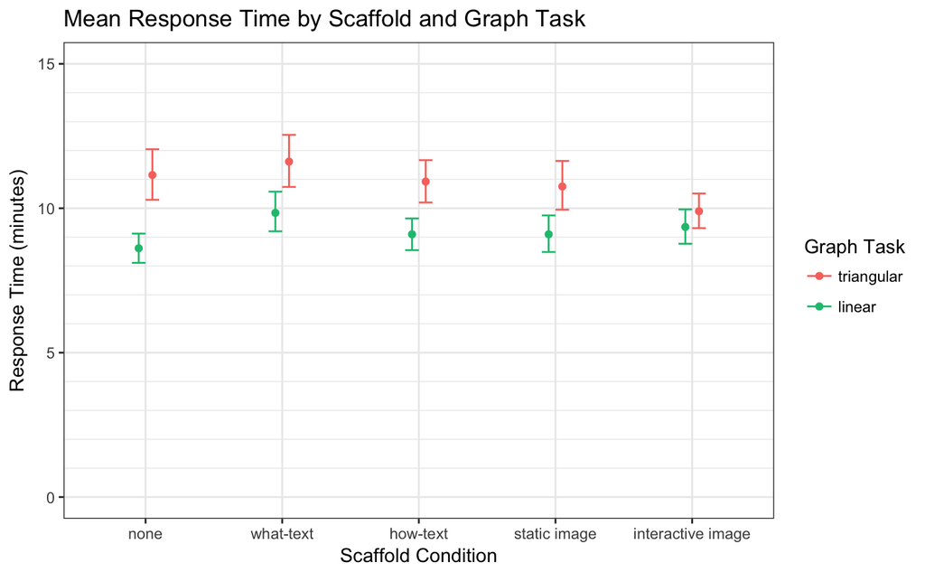

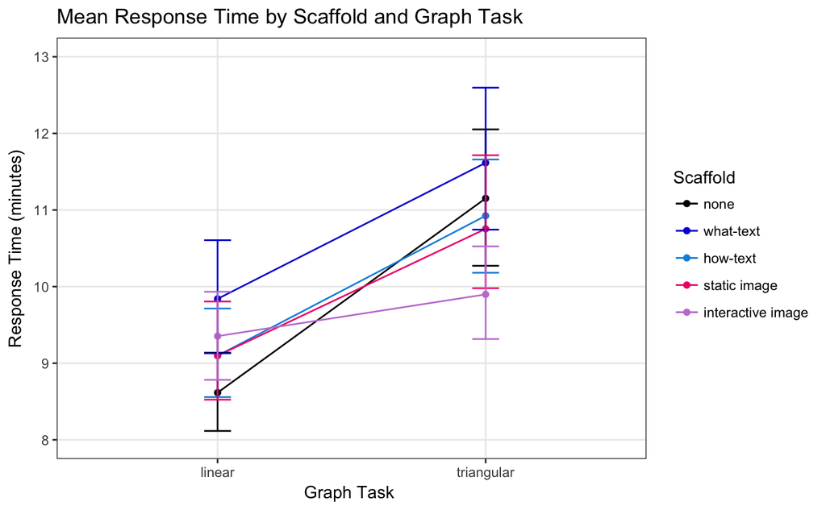

`IXN Graph Type & Order` There was a significant interaction between graph-type and graph-order,

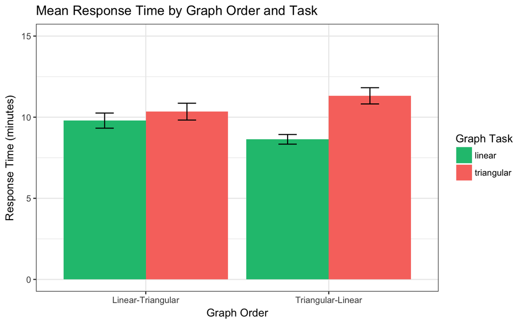

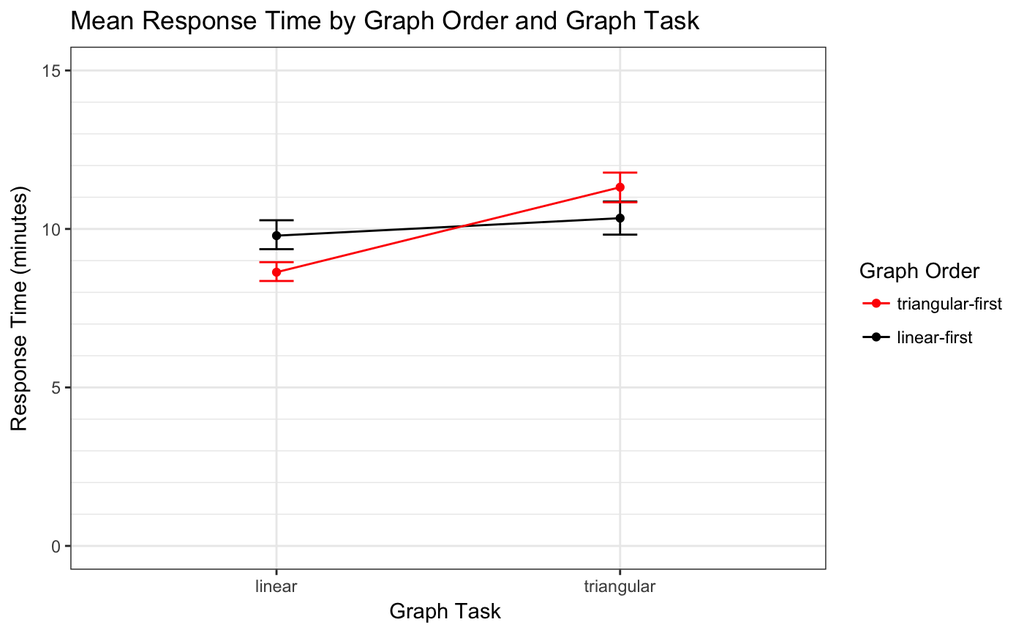

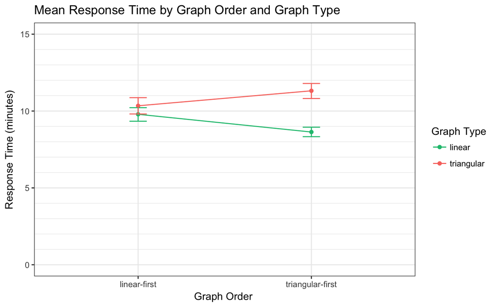

`IXN Graph Type & Scenario` There was a significant interaction between graph-type and scenario

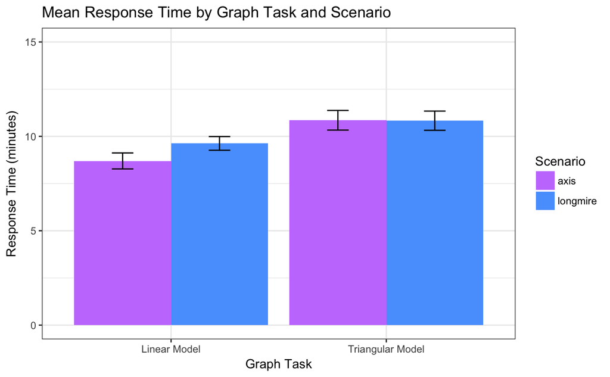

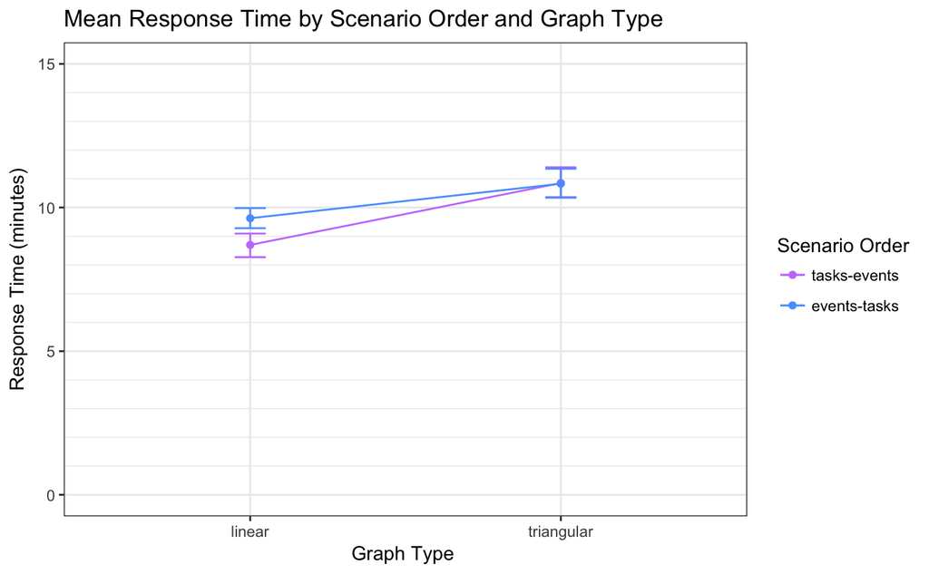

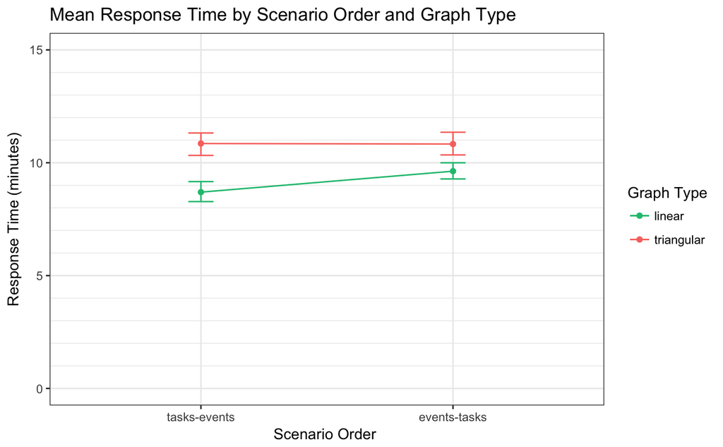

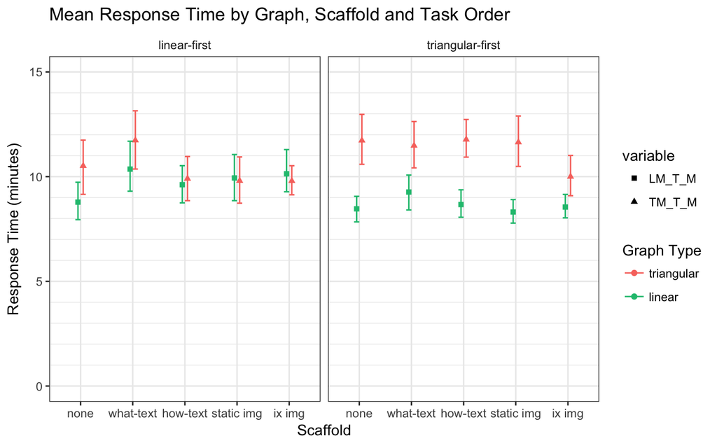

[figure not shown]

#### 2. Results: Response Accuracy

```
       Linear      Triangular
```

condition mean sd mean sd  
0 11.0 2.3 6.9 4.5 1 11.1 2.2 8.8 4.3 2 10.9 2.1 8.7 4.7 3 10.9 2.2 8.6 4.6 4 10.9 1.9 10.7 3.4 All 11.0 2.1 8.8 4.4

##### Construct a mixed ANOVA

1. Explore descriptives for each factor
2. Construct contrasts
3. compute the ANOVA model

```
Converting "subject" to factor for ANOVA.Data is unbalanced (unequal N per group). Make sure you specified a well-considered value for the type argument to ezANOVA().
```

|  | Effect | DFn | DFd | F | p | p<.05 | ges |
| --- | --- | --- | --- | --- | --- | --- | --- |
| 2 | condition | 4 | 297 | 4.30982323 | 2.100960e-03 | * | 0.0378305107 |
| 3 | order | 1 | 297 | 0.75397100 | 3.859230e-01 |  | 0.0017166417 |
| 4 | lm_scenarios | 1 | 297 | 22.28978056 | 3.618430e-06 | * | 0.0483773143 |
| 9 | variable | 1 | 297 | 97.66603968 | 4.249544e-20 | * | 0.0959172187 |
| 5 | condition:order | 4 | 297 | 0.69255727 | 5.976030e-01 |  | 0.0062784375 |
| 6 | condition:lm_scenarios | 4 | 297 | 1.30152443 | 2.694854e-01 |  | 0.0117343006 |
| 7 | order:lm_scenarios | 1 | 297 | 0.03981309 | 8.419830e-01 |  | 0.0000907941 |
| 10 | condition:variable | 4 | 297 | 9.99194713 | 1.340564e-07 | * | 0.0416099521 |
| 11 | order:variable | 1 | 297 | 3.35133548 | 6.815241e-02 |  | 0.0036273087 |
| 12 | lm_scenarios:variable | 1 | 297 | 34.80373745 | 9.923566e-09 | * | 0.0364295784 |

[output cut: 5 more lines]

```
NA
```

MIXED EFFECTS ANOVA ON SCORE Main effect of Scaffold F(4,297) = 4.31, p < .01 Main effect of Scenario F(1,297) = 22.29, p < .001 Main effect of Graph F(1,297) = 97.67, p < .001 Interaction of Scaffold and Graph F(4,297) = 9.99, p <.001 Interaction of Graph and Scenario F(1,297) = 34.80, p <.001

4. Interpret significant effects  
   `Main Effect: Graph Type`

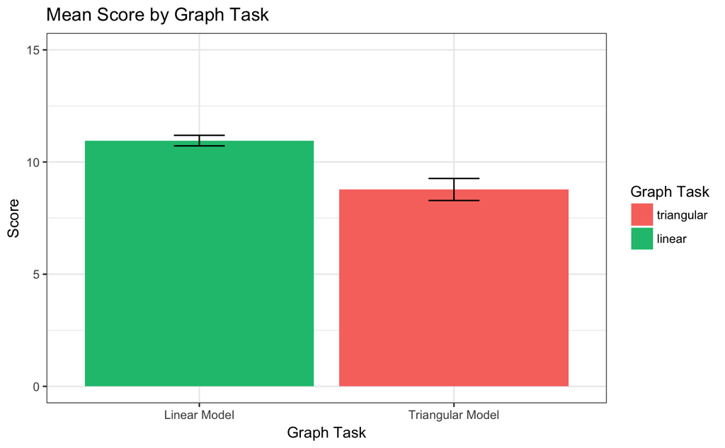

`Main Effect of Scaffold : superceded by interaction`

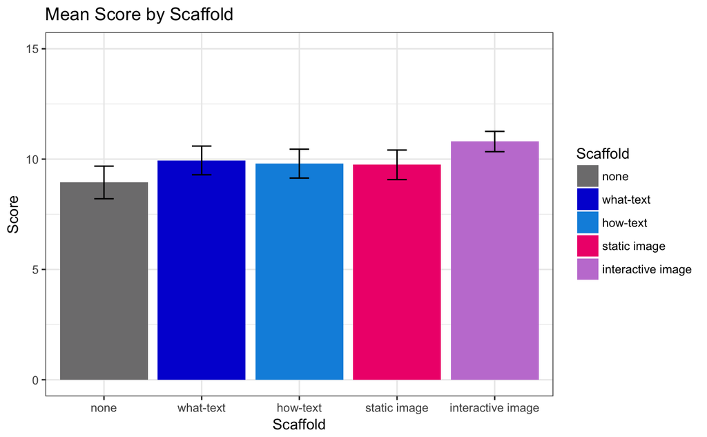

`Main Effect of Scenario : superceded by interaction`

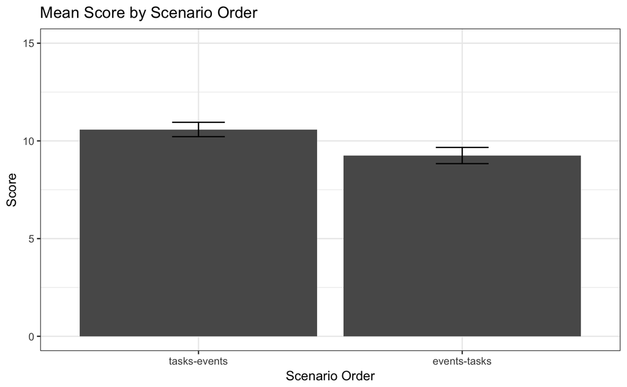

`IXN Graph Type & Scaffold` There was a significant interaction between graph-type and the scaffold condition,

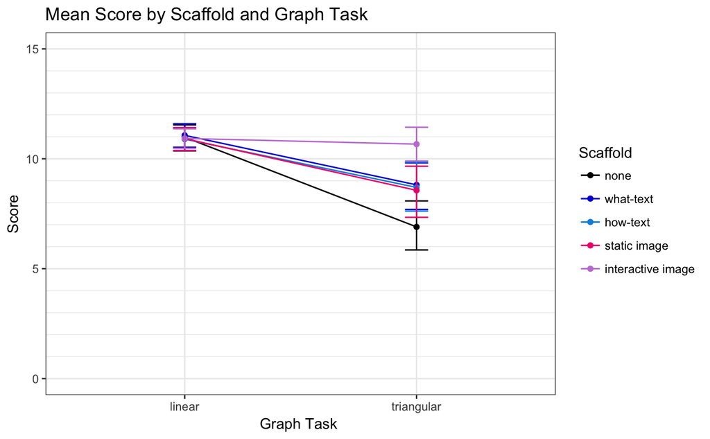

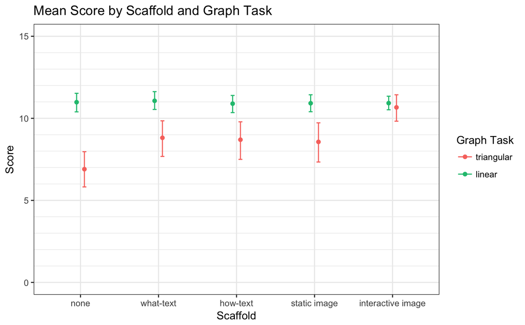

`IXN Graph Type & Scenario` There was a significant interaction between graph-type and scenario

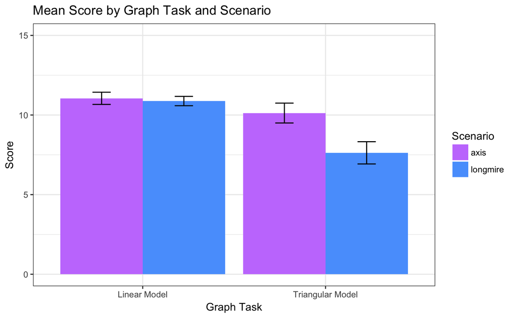

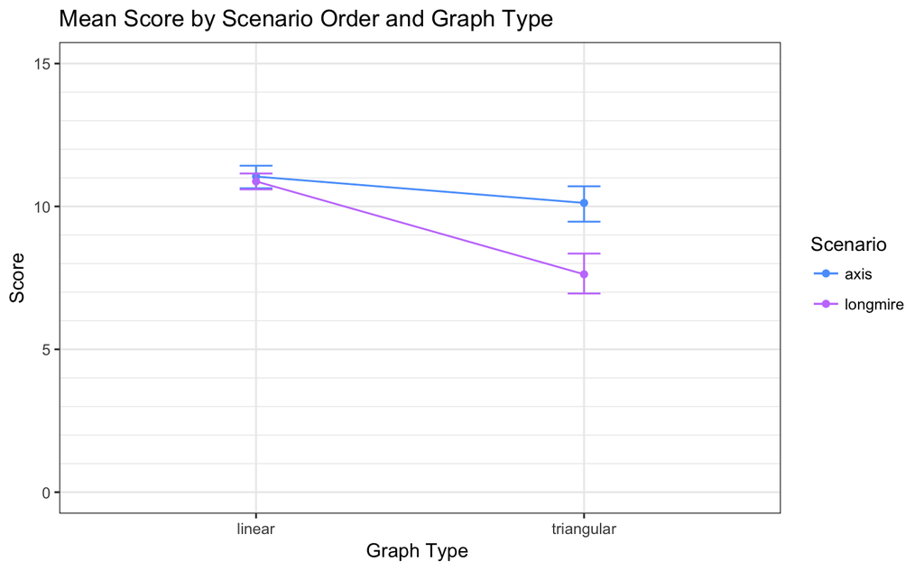

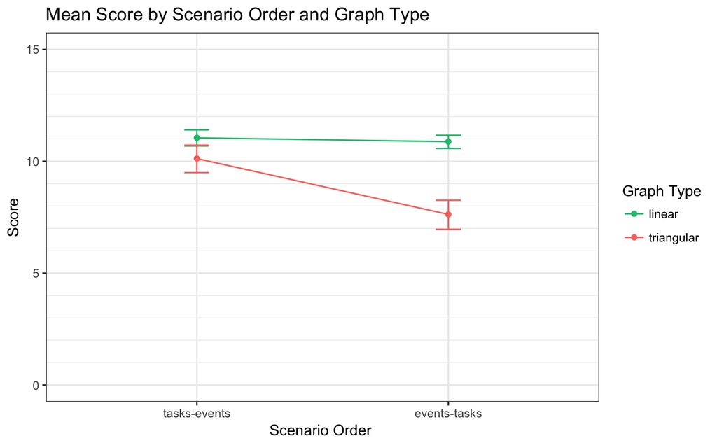

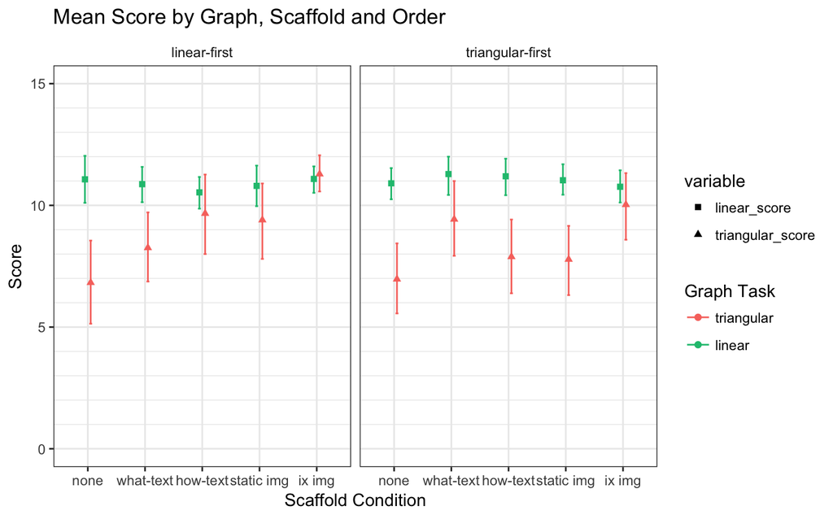

[figure not shown]

[figure not shown]

#### 4. Results: Drawing Score

> What were the means and variance of drawing times and scores?

|  | subject | condition | order | lm_scenarios | drawScore |
| --- | --- | --- | --- | --- | --- |
| nbr.val | NA | NA | NA | NA | 317.0000000 |
| nbr.null | NA | NA | NA | NA | 9.0000000 |
| nbr.na | NA | NA | NA | NA | 0.0000000 |
| min | NA | NA | NA | NA | 0.0000000 |
| max | NA | NA | NA | NA | 12.0000000 |
| range | NA | NA | NA | NA | 12.0000000 |
| sum | NA | NA | NA | NA | 3257.0000000 |
| median | NA | NA | NA | NA | 11.0000000 |
| mean | NA | NA | NA | NA | 10.2744479 |
| SE.mean | NA | NA | NA | NA | 0.1607072 |

[output cut: 4 more lines]

|  | subject | condition | order | lm_scenarios | DT_T_M |
| --- | --- | --- | --- | --- | --- |
| nbr.val | NA | NA | NA | NA | 317.0000000 |
| nbr.null | NA | NA | NA | NA | 0.0000000 |
| nbr.na | NA | NA | NA | NA | 0.0000000 |
| min | NA | NA | NA | NA | 4.4200000 |
| max | NA | NA | NA | NA | 32.1300000 |
| range | NA | NA | NA | NA | 27.7100000 |
| sum | NA | NA | NA | NA | 4424.3600000 |
| median | NA | NA | NA | NA | 13.1900000 |
| mean | NA | NA | NA | NA | 13.9569716 |
| SE.mean | NA | NA | NA | NA | 0.2579292 |

[output cut: 4 more lines]

> Are drawing time and score correlated?

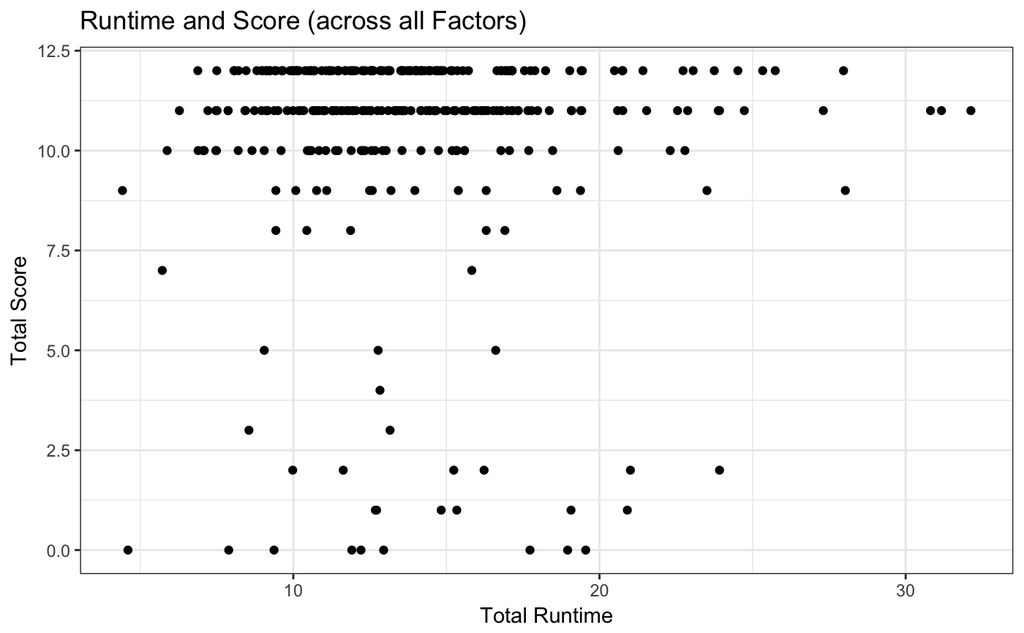

> What were the mean time and scores by scaffold group on the drawing task?

##### Construct an ANOVA for drawing score

1. Explore descriptives for each factor

```
                              Df Sum Sq Mean Sq F value  Pr(>F)
condition                      4   76.8   19.19   2.443 0.04681 *
order                          1    0.1    0.06   0.007 0.93269
lm_scenarios                   1   86.3   86.28  10.986 0.00103 **
condition:order                4   45.5   11.39   1.450 0.21762
condition:lm_scenarios         4   33.7    8.41   1.071 0.37085
order:lm_scenarios             1    8.6    8.56   1.090 0.29723
condition:order:lm_scenarios   4    3.5    0.89   0.113 0.97801
Residuals                    297 2332.7    7.85
---
Signif. codes:  0 ‘***’ 0.001 ‘**’ 0.01 ‘*’ 0.05 ‘.’ 0.1 ‘ ’ 1

Call:
aov(formula = value ~ condition * order * lm_scenarios, data = l_draw_s)

Residuals:
     Min       1Q   Median       3Q      Max
-10.4737  -0.3571   0.6429   1.3750   4.0588

Coefficients:
                                 Estimate Std. Error t value Pr(>|t|)
(Intercept)                     10.310827   0.159567  64.617  < 2e-16 ***
condition1                      -0.951975   0.321696  -2.959  0.00333 **
condition2                       0.107967   0.330540   0.327  0.74417
condition3                       0.016951   0.312185   0.054  0.95673
condition4                       0.325334   0.318944   1.020  0.30854
order1                          -0.001541   0.159567  -0.010  0.99230
lm_scenarios1                    0.522822   0.159567   3.276  0.00118 **
condition1:order1                0.089804   0.321696   0.279  0.78032
condition2:order1               -0.510435   0.330540  -1.544  0.12359
condition3:order1                0.607096   0.312185   1.945  0.05276 .
condition4:order1                0.075201   0.318944   0.236  0.81376
condition1:lm_scenarios1         0.480827   0.321696   1.495  0.13606
condition2:lm_scenarios1        -0.029028   0.330540  -0.088  0.93008
condition3:lm_scenarios1        -0.333933   0.312185  -1.070  0.28564
condition4:lm_scenarios1         0.238339   0.318944   0.747  0.45549
order1:lm_scenarios1            -0.164619   0.159567  -1.032  0.30307
condition1:order1:lm_scenarios1 -0.161145   0.321696  -0.501  0.61680
condition2:order1:lm_scenarios1  0.127643   0.330540   0.386  0.69965
condition3:order1:lm_scenarios1 -0.090937   0.312185  -0.291  0.77103
condition4:order1:lm_scenarios1  0.050779   0.318944   0.159  0.87361
---
Signif. codes:  0 ‘***’ 0.001 ‘**’ 0.01 ‘*’ 0.05 ‘.’ 0.1 ‘ ’ 1

Residual standard error: 2.803 on 297 degrees of freedom
Multiple R-squared:  0.09833,   Adjusted R-squared:  0.04065
F-statistic: 1.705 on 19 and 297 DF,  p-value: 0.03457
```

##### Construct an ANOVA for drawing time

1. Explore descriptives for each factor

```
                              Df Sum Sq Mean Sq F value Pr(>F)
condition                      4    120   29.94   1.450 0.2176
order                          1     32   32.10   1.554 0.2135
lm_scenarios                   1      8    7.51   0.364 0.5470
condition:order                4    182   45.53   2.205 0.0685 .
condition:lm_scenarios         4    100   25.08   1.215 0.3047
order:lm_scenarios             1      5    5.13   0.248 0.6185
condition:order:lm_scenarios   4     84   20.88   1.011 0.4019
Residuals                    297   6134   20.65
---
Signif. codes:  0 ‘***’ 0.001 ‘**’ 0.01 ‘*’ 0.05 ‘.’ 0.1 ‘ ’ 1

Call:
aov(formula = value ~ condition * order * lm_scenarios, data = l_draw_t)

Residuals:
    Min      1Q  Median      3Q     Max
-8.5390 -2.8862 -0.7616  2.2737 15.7289

Coefficients:
                                Estimate Std. Error t value Pr(>|t|)
(Intercept)                      13.9502     0.2587  53.914   <2e-16 ***
condition1                       -0.6710     0.5216  -1.286   0.1994
condition2                        1.0357     0.5360   1.932   0.0543 .
condition3                       -0.0184     0.5062  -0.036   0.9710
condition4                       -0.1881     0.5172  -0.364   0.7163
order1                           -0.3524     0.2587  -1.362   0.1743
lm_scenarios1                     0.1623     0.2587   0.627   0.5310
condition1:order1                 0.5271     0.5216   1.010   0.3131
condition2:order1                 0.8501     0.5360   1.586   0.1138
condition3:order1                -1.2550     0.5062  -2.479   0.0137 *
condition4:order1                -0.1453     0.5172  -0.281   0.7790
condition1:lm_scenarios1         -0.9051     0.5216  -1.735   0.0838 .
condition2:lm_scenarios1         -0.2610     0.5360  -0.487   0.6267
condition3:lm_scenarios1          0.0315     0.5062   0.062   0.9504
condition4:lm_scenarios1          0.4181     0.5172   0.809   0.4194
order1:lm_scenarios1             -0.1396     0.2587  -0.539   0.5900
condition1:order1:lm_scenarios1   0.7647     0.5216   1.466   0.1437
condition2:order1:lm_scenarios1  -0.7072     0.5360  -1.319   0.1881
condition3:order1:lm_scenarios1   0.4314     0.5062   0.852   0.3948
condition4:order1:lm_scenarios1  -0.2009     0.5172  -0.388   0.6979
---
Signif. codes:  0 ‘***’ 0.001 ‘**’ 0.01 ‘*’ 0.05 ‘.’ 0.1 ‘ ’ 1

Residual standard error: 4.544 on 297 degrees of freedom
Multiple R-squared:  0.0796,    Adjusted R-squared:  0.02072
F-statistic: 1.352 on 19 and 297 DF,  p-value: 0.1499
```

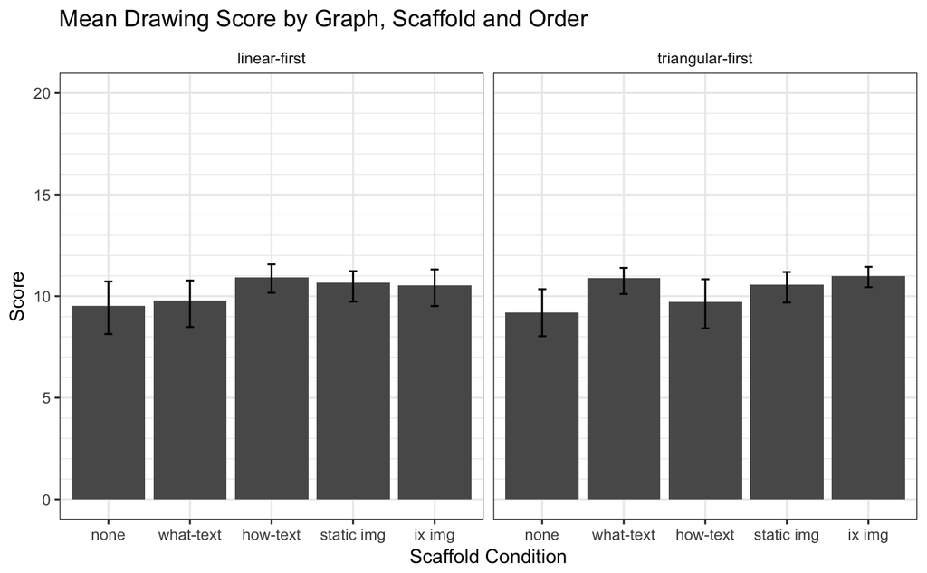

> Drawing Interpretation

### Summaries Drawing Interpretation

```
Triangular (right angle) Triangular Linear Model Scatterplot Other Triangular (asymmetric)
```

data: tbl X-squared = 38.533, df = 20, p-value = 0.007617

Triangular (right angle) Triangular Linear Model Scatterplot Other 44 229 17 3 2 Triangular (asymmetric) 22

> Pairwise comparisons & simple contrasts